# classify

```r
library(tidyverse)
library(brms)
```

I’ll use [brms](https://paul-buerkner.github.io/brms/) to build the model. `brms` is a high-level package for interfacing with Stan. It has two “backends”, other packages that handle most of the communication with R [RStan](https://github.com/stan-dev/rstan) and [cmdstanr](https://mc-stan.org/cmdstanr/). `cmdstanr` is newer and takes a bit more setup, but it offers many advantages. It’s worth taking a look at their [Getting Started vignette](https://mc-stan.org/cmdstanr/articles/cmdstanr.html). The most critical steps are the following, which install the `cmdstanr` package and then uses `cmdstanr` to install `cmdstan`.

```r
# install cmdstanr
install.packages("cmdstanr", repos = c("https://mc-stan.org/r-packages/", getOption("repos")))
# install cmdstan
cmdstanr::install_cmdstan()
```

# Data

The following is a rather dense function. Feel free to skim through it; it’s main purpose is to load the data and reshape it into a “tidier” shape, something that `brms` will know how to work with.

```r
munge <- function(fnames){
  d <- map(fnames,
           function(x) R.matlab::readMat(x)[[1]]) %>%
    map_depth(
      3,
      function(x) x %>%
        magrittr::set_colnames(c("feature1","feature2","object")) %>%
        as_tibble(rownames = "trial")) %>%
    map_depth(.depth = 1, bind_rows, .id = "region") %>%
    bind_rows(.id = "participant") %>%
    pivot_longer(
      cols=c("feature1", "feature2", 'object'),
      names_to = "class") %>%
    mutate(
      region = factor(
        region,
        levels = 1:26,
        labels = c('V1v', 'V1d', 'V2v', 'V2d', 'V3v', 'V3d', 'hV4', 'VO1', 'VO2', 'PHC12','TO2' ,'TO1', 'LO2', 'LO1', 'V3AB', 'IPS0', 'IPS1', 'IPS2', 'IPS3', 'IPS4', 'IPS5','SPL1','FEF','PHC', 'PRC', 'HC')),
      class = factor(class),
      value = as.logical(value),
      trial = factor(trial),
      participant = factor(participant))
  d
}
```

The function can be used to load a participant’s data.

```r
d <- munge(here::here("data-raw", "roi_class_results_LDA.mat"))
d
```

```
## # A tibble: 24,960 x 5
##    participant region trial class    value
##    <fct>       <fct>  <fct> <fct>    <lgl>
##  1 1           V1v    1     feature1 TRUE
##  2 1           V1v    1     feature2 TRUE
##  3 1           V1v    1     object   TRUE
##  4 1           V1v    2     feature1 TRUE
##  5 1           V1v    2     feature2 FALSE
##  6 1           V1v    2     object   FALSE
##  7 1           V1v    3     feature1 FALSE
##  8 1           V1v    3     feature2 TRUE
##  9 1           V1v    3     object   FALSE
## 10 1           V1v    4     feature1 TRUE
## # … with 24,950 more rows
```

Let’s make a quick plot of the data. This will show the average classification accuracy (across trials) for each region, broken down by the three kinds of classification.

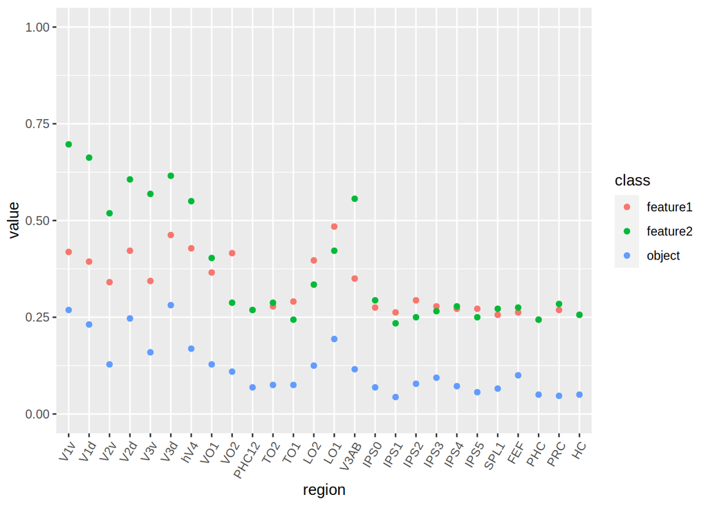

```r
plot_d <- function(d){
  d %>%
    group_by(region, class) %>%
    summarise(value = mean(value), .groups = "drop") %>%
    ggplot(aes(x=region, y = value, color=class)) +
    geom_point() +
    ylim(c(0,1)) +
    theme(axis.text.x = element_text(angle=60, hjust=1))
}

plot_d(d)
```

From this, we see that the two features are generally easier classify, as compared to the object (this makes sense, given that chance for the object classification is lower). It looks like there are difference between the predictability of the two features, especially in the early visual regions.

# Modeling

As a rule of thumb, I advice starting with simpler models, slowly adding features. All of these models will involve some kind of logistic regression, but we’ll see that they can get rather complex.

## Model 1

For this model, let $y_{i,j}$ be the observation (either a 0 or 1) on trial $i$ and region $j$. We’ll say that this is distributed according to a Bernoulli distribution, parameterized by $p_{i,j}$ – the probability of getting a 1. We’re going to model this probability with logistic regression. So, rather than modeling each $p_{i,j}$ directly, we will instead model the result of passing $p_{i,j}$ through a logit function. The logit takes a value between 0 and 1 (e.g., a probability) and outputs a value between positive and negative infinity. We then build a linear model of the result of that transformed probability. In this first model, we’ll say that the logit is equal to some intercept parameter, $\beta_0$, plus a parameter governing how easily each class is predicted $\beta_1$,[^1] plus a parameter that governs how well each region is at predicting *any* class, $\alpha^{region}_{j}$.

As with frequentist modeling, there is a question of whether we each of the effects should be ‘fixed’ or ‘random’. As with frequentist modeling, there are many different ways of talking about what these terms even mean. I usually find it helpful to think about whether I expect one level to have information about other levels. In the case of regions, I expect that knowing the predictive accuracy of one region provides a lot of information about the predictive accuracy of another region. So, it makes sense to think of the effect of region as ‘random’, to estimate it hierarchically. Put another way, it makes sense to [pool information about the regions together](https://mc-stan.org/rstanarm/articles/pooling.html).

It might make sense to estimate the effect of class hierarchically also, since accuracy on feature 1 is probably informative about the accuracy of feature 2. But with only 3 levels of class (feature 1, feature 2, and object), it becomes very hard to estimate the variability in the effect of class, meaning that it’s hard to effectively pool information across classes. For this reason, the effect of class will be estimated without a hierarchy.

In math, we could express this model as follows.

$$y_{i,j} \sim bernoulli(p_{i,j}) \\
\log ( \frac{p_{i,j}}{1-p_{i,j}} ) = \beta_0 + \beta_1x_{1,i} + \alpha^{region}_{j} \\
\alpha^{region} \sim normal(0, \sigma^{region}) \\
\sigma^{region} \sim student\_t(3, 0, 2.5) \\
\beta_0,\beta_1 \sim normal(0, 2.5) \\$$

The last two lines, beginning with $\sigma^{region}$ and $\beta_0,\beta_1$, are the priors. These are a kind of default prior. There is a lot of data, so I expect that the priors won’t matter too much (more on this later).

## Coding model 1

It’ll be worth reading through some of the documentation for `brms` (e.g., the above link, also [here](https://www.jstatsoft.org/article/view/v080i01), and see [here](https://paul-buerkner.github.io/blog/brms-blogposts/) for a neat collection of blog posts on `brms`).

One of the great things about `brms` is that we can define models using the same syntax as the `lm`, `glm`, and `lmer` functions. The above model would be defined as follows, excluding the priors.

```r
f <- brmsformula(
  value ~ 0 + Intercept + class + (1 || region),
  family = bernoulli)
```

`brms` puts default priors on a few of the parameters, and leaves other priors undefined. The function `get_prior` is helpful for seeing what parameters will need priors, or seeing the defaults.

```r
get_prior(f,d)
```

```
##                 prior class          coef  group resp dpar nlpar bound
##                (flat)     b
##                (flat)     b classfeature2
##                (flat)     b   classobject
##                (flat)     b     Intercept
##  student_t(3, 0, 2.5)    sd
##  student_t(3, 0, 2.5)    sd               region
##  student_t(3, 0, 2.5)    sd     Intercept region
##        source
##       default
##  (vectorized)
##  (vectorized)
##  (vectorized)
##       default
##  (vectorized)
##  (vectorized)
```

I always find that output confusing. To use the math symbols defined above, this output is saying is that there are uniformly flat priors on $\beta_0$ and $\beta_1$, and that there is a $student(3, 0, 2.5)$ prior on the the effect of region. So, all we need is to set a prior on the effect of class. For this, use the `prior` function.

```r
p <- prior(normal(0, 2.5), class = "b")
```

The model can then be fit as follows. Note that I’m only running 3 chains, but that’s mostly so that this demo doesn’t take too long. In practice, you should probably run 4.

```r
fit <- brm(
  formula = f,
  data = d,
  prior = p,
  chains = 3,
  cores = 3,
  backend = "cmdstanr")
```

```
## Running MCMC with 3 parallel chains...
##
## Chain 1 Iteration:    1 / 2000 [  0%]  (Warmup)
## Chain 2 Iteration:    1 / 2000 [  0%]  (Warmup)
## Chain 3 Iteration:    1 / 2000 [  0%]  (Warmup)
## Chain 1 Iteration:  100 / 2000 [  5%]  (Warmup)
## Chain 2 Iteration:  100 / 2000 [  5%]  (Warmup)
## Chain 3 Iteration:  100 / 2000 [  5%]  (Warmup)
## Chain 1 Iteration:  200 / 2000 [ 10%]  (Warmup)
## Chain 2 Iteration:  200 / 2000 [ 10%]  (Warmup)
## Chain 3 Iteration:  200 / 2000 [ 10%]  (Warmup)
## Chain 1 Iteration:  300 / 2000 [ 15%]  (Warmup)
## Chain 2 Iteration:  300 / 2000 [ 15%]  (Warmup)
## Chain 3 Iteration:  300 / 2000 [ 15%]  (Warmup)
## Chain 1 Iteration:  400 / 2000 [ 20%]  (Warmup)
## Chain 2 Iteration:  400 / 2000 [ 20%]  (Warmup)
## Chain 3 Iteration:  400 / 2000 [ 20%]  (Warmup)
## Chain 1 Iteration:  500 / 2000 [ 25%]  (Warmup)
## Chain 2 Iteration:  500 / 2000 [ 25%]  (Warmup)
## Chain 3 Iteration:  500 / 2000 [ 25%]  (Warmup)
## Chain 1 Iteration:  600 / 2000 [ 30%]  (Warmup)
## Chain 2 Iteration:  600 / 2000 [ 30%]  (Warmup)
## Chain 3 Iteration:  600 / 2000 [ 30%]  (Warmup)
## Chain 1 Iteration:  700 / 2000 [ 35%]  (Warmup)
## Chain 2 Iteration:  700 / 2000 [ 35%]  (Warmup)
## Chain 3 Iteration:  700 / 2000 [ 35%]  (Warmup)
## Chain 2 Iteration:  800 / 2000 [ 40%]  (Warmup)
## Chain 1 Iteration:  800 / 2000 [ 40%]  (Warmup)
## Chain 3 Iteration:  800 / 2000 [ 40%]  (Warmup)
## Chain 2 Iteration:  900 / 2000 [ 45%]  (Warmup)
## Chain 1 Iteration:  900 / 2000 [ 45%]  (Warmup)
## Chain 3 Iteration:  900 / 2000 [ 45%]  (Warmup)
## Chain 2 Iteration: 1000 / 2000 [ 50%]  (Warmup)
## Chain 2 Iteration: 1001 / 2000 [ 50%]  (Sampling)
## Chain 1 Iteration: 1000 / 2000 [ 50%]  (Warmup)
## Chain 1 Iteration: 1001 / 2000 [ 50%]  (Sampling)
## Chain 3 Iteration: 1000 / 2000 [ 50%]  (Warmup)
## Chain 3 Iteration: 1001 / 2000 [ 50%]  (Sampling)
## Chain 1 Iteration: 1100 / 2000 [ 55%]  (Sampling)
## Chain 2 Iteration: 1100 / 2000 [ 55%]  (Sampling)
```

[output cut: 20 more lines]

```
## Chain 3 Iteration: 1800 / 2000 [ 90%]  (Sampling)
## Chain 1 Iteration: 1900 / 2000 [ 95%]  (Sampling)
## Chain 2 Iteration: 1800 / 2000 [ 90%]  (Sampling)
## Chain 3 Iteration: 1900 / 2000 [ 95%]  (Sampling)
## Chain 1 Iteration: 2000 / 2000 [100%]  (Sampling)
## Chain 1 finished in 108.5 seconds.
## Chain 2 Iteration: 1900 / 2000 [ 95%]  (Sampling)
## Chain 3 Iteration: 2000 / 2000 [100%]  (Sampling)
## Chain 3 finished in 110.8 seconds.
## Chain 2 Iteration: 2000 / 2000 [100%]  (Sampling)
## Chain 2 finished in 113.6 seconds.
##
## All 3 chains finished successfully.
## Mean chain execution time: 111.0 seconds.
## Total execution time: 113.8 seconds.
```

## Checking validity of posterior distribution

It’s important to remember that Bayesian analyses, done with some kind of Monte Carlo estimation, provide only an approximation to the true posterior. It’s very important to check whether the approximation is any good. There are many ways to do those checks. Some of the checks can be looked at by printing the fit object.

```r
fit
```

```
##  Family: bernoulli
##   Links: mu = logit
## Formula: value ~ 0 + Intercept + class + (1 || region)
##    Data: d (Number of observations: 24960)
## Samples: 3 chains, each with iter = 2000; warmup = 1000; thin = 1;
##          total post-warmup samples = 3000
##
## Group-Level Effects:
## ~region (Number of levels: 26)
##               Estimate Est.Error l-95% CI u-95% CI Rhat Bulk_ESS Tail_ESS
## sd(Intercept)     0.53      0.08     0.40     0.72 1.00      255      456
##
## Population-Level Effects:
##               Estimate Est.Error l-95% CI u-95% CI Rhat Bulk_ESS Tail_ESS
## Intercept        -0.74      0.11    -0.95    -0.52 1.02      173      358
## classfeature2     0.24      0.03     0.18     0.30 1.00     1111     1750
## classobject      -1.35      0.04    -1.43    -1.27 1.00     1298     1699
##
## Samples were drawn using sample(hmc). For each parameter, Bulk_ESS
## and Tail_ESS are effective sample size measures, and Rhat is the potential
## scale reduction factor on split chains (at convergence, Rhat = 1).
```

Look for the coluns about ESS (effective sample size) and Rhat. ESS is a measure of how much information is contained in the approximation (roughly analogous to the number of observations in an experiment). There are many opinions about what ESS is sufficient. It’ll usually depend on what exactly you need to estimate.

The Rhat value is a statistic that looks at whether the chains have converged to the same posterior. It’s a problem if Rhat is above 1.1, but anything above ~1.01 should arouse some suspicion.

The package `shinystan` provides a great tool for exploring more aspects of the model, including diagnostics. It can be launched as follows.

```r
shinystan::launch_shinystan(fit)
```

## Analyzing results

There are always many ways to look at the fitted results. This model happened to converge easily, so I’m first going to focus on the predictions of the model. Again, the following function is rather dense. It uses the `brms` function `posterior_epred` to generate predictions from the fitted model, and then uses a bunch of `tidyverse` functions to reshape and summarize those predictions.

```r
get_predictions <- function(.fit, .d, ...){

  predictions <- posterior_epred(.fit, cores=3) %>%
    magrittr::set_colnames(1:ncol(.)) %>%
    as_tibble() %>%
    mutate(.draw = 1:n()) %>%
    pivot_longer(
      cols = c(-.draw),
      names_to = "observation",
      names_transform = list(observation = as.numeric),
      values_to = "post") %>%
    group_nest(.draw) %>%
    mutate(data = map(.x=data, .f= bind_cols, .d)) %>%
    unnest(data) %>%
    select(-value) %>%
    group_by(...) %>%
    summarise(
      ymin = quantile(post, .025),
      ymax = quantile(post, .975),
      .groups = "drop")
  predictions
}
```

The function can be called like so.

```r
predictions1 <- get_predictions(fit, d, class, region)
```

```r
predictions1
```

```
## # A tibble: 78 x 4
##    class    region  ymin  ymax
##    <fct>    <fct>  <dbl> <dbl>
##  1 feature1 V1v    0.505 0.574
##  2 feature1 V1d    0.470 0.539
##  3 feature1 V2v    0.358 0.425
##  4 feature1 V2d    0.466 0.532
##  5 feature1 V3v    0.390 0.458
##  6 feature1 V3d    0.496 0.566
##  7 feature1 hV4    0.415 0.489
##  8 feature1 VO1    0.324 0.390
##  9 feature1 VO2    0.292 0.357
## 10 feature1 PHC12  0.214 0.275
## # … with 68 more rows
```

Next, we’ll re-generate a plot of the data, and then add to it the computed model predictions as vertical bars.

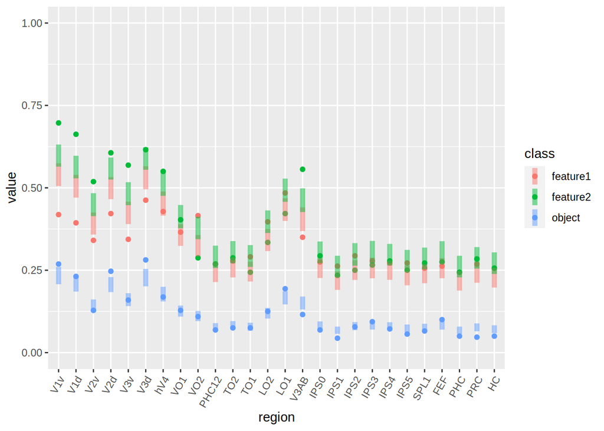

```r
plot_d(d) +
  geom_linerange(
    aes(ymin=ymin,ymax=ymax, x=region, color=class),
    alpha = 0.5,
    size = 2,
    data = predictions1,
    inherit.aes = FALSE)
```

This result might make sense. What we see is that the posteriors are close to the observations, but they do not quite match the variability across regions. That is, the model struggles to capture how some regions are particularly good at some classes. The model can only capture variability in the average accuracy of each class and variability in the average accuracy for each region, but it does not yet capture how these two might interact.

## Model 2

This model will be almost identical to the first. The difference will be the addition of another parameter, $\alpha^{class}_j$, which controls how well each region is at predicting each class.

$$y_{i,j} \sim bernoulli(p_{i,j}) \\
\log ( \frac{p_{i,j}}{1-p_{i,j}} ) = \beta_0 + \beta_{1}x_{1,i} + \alpha_{j}^{region} + \alpha_j^{class} \\
\alpha^{region} \sim normal(0, \sigma^{region}) \\
\beta^{class} \sim normal(0, \sigma^{class}) \\
\sigma^{region},\sigma^{class} \sim student\_t(3, 0, 2.5) \\
\beta_0,\beta_{1,j} \sim normal(0, 2.5) \\$$

This is presumably a very important addition, for two reasons. First, Model 1 clearly did not fit the data, meaning that it was not a sufficient model. Second, we’d expect for theoretical regions that some regions are better at predicting each features (or, we’d hope that, e.g., some regions are better at predicting features relative to objects :) ).

This new model is defined as follows.

```r
f2 <- brmsformula(
  value ~ 0 + Intercept + class + (class || region),
  family = bernoulli)
```

```r
fit2 <- brm(
  formula = f2,
  data = d,
  prior = p,
  chains = 3,
  cores = 3,
  backend = "cmdstanr")
```

```
## Running MCMC with 3 parallel chains...
##
## Chain 1 Iteration:    1 / 2000 [  0%]  (Warmup)
## Chain 2 Iteration:    1 / 2000 [  0%]  (Warmup)
## Chain 3 Iteration:    1 / 2000 [  0%]  (Warmup)
## Chain 3 Iteration:  100 / 2000 [  5%]  (Warmup)
## Chain 2 Iteration:  100 / 2000 [  5%]  (Warmup)
## Chain 1 Iteration:  100 / 2000 [  5%]  (Warmup)
## Chain 3 Iteration:  200 / 2000 [ 10%]  (Warmup)
## Chain 1 Iteration:  200 / 2000 [ 10%]  (Warmup)
## Chain 2 Iteration:  200 / 2000 [ 10%]  (Warmup)
## Chain 3 Iteration:  300 / 2000 [ 15%]  (Warmup)
## Chain 1 Iteration:  300 / 2000 [ 15%]  (Warmup)
## Chain 2 Iteration:  300 / 2000 [ 15%]  (Warmup)
## Chain 1 Iteration:  400 / 2000 [ 20%]  (Warmup)
## Chain 3 Iteration:  400 / 2000 [ 20%]  (Warmup)
## Chain 2 Iteration:  400 / 2000 [ 20%]  (Warmup)
## Chain 3 Iteration:  500 / 2000 [ 25%]  (Warmup)
## Chain 1 Iteration:  500 / 2000 [ 25%]  (Warmup)
## Chain 2 Iteration:  500 / 2000 [ 25%]  (Warmup)
## Chain 3 Iteration:  600 / 2000 [ 30%]  (Warmup)
## Chain 1 Iteration:  600 / 2000 [ 30%]  (Warmup)
## Chain 2 Iteration:  600 / 2000 [ 30%]  (Warmup)
## Chain 3 Iteration:  700 / 2000 [ 35%]  (Warmup)
## Chain 1 Iteration:  700 / 2000 [ 35%]  (Warmup)
## Chain 2 Iteration:  700 / 2000 [ 35%]  (Warmup)
## Chain 3 Iteration:  800 / 2000 [ 40%]  (Warmup)
## Chain 1 Iteration:  800 / 2000 [ 40%]  (Warmup)
## Chain 2 Iteration:  800 / 2000 [ 40%]  (Warmup)
## Chain 3 Iteration:  900 / 2000 [ 45%]  (Warmup)
## Chain 1 Iteration:  900 / 2000 [ 45%]  (Warmup)
## Chain 2 Iteration:  900 / 2000 [ 45%]  (Warmup)
## Chain 3 Iteration: 1000 / 2000 [ 50%]  (Warmup)
## Chain 3 Iteration: 1001 / 2000 [ 50%]  (Sampling)
## Chain 1 Iteration: 1000 / 2000 [ 50%]  (Warmup)
## Chain 1 Iteration: 1001 / 2000 [ 50%]  (Sampling)
## Chain 2 Iteration: 1000 / 2000 [ 50%]  (Warmup)
## Chain 2 Iteration: 1001 / 2000 [ 50%]  (Sampling)
## Chain 3 Iteration: 1100 / 2000 [ 55%]  (Sampling)
## Chain 1 Iteration: 1100 / 2000 [ 55%]  (Sampling)
```

[output cut: 20 more lines]

```
## Chain 1 Iteration: 1800 / 2000 [ 90%]  (Sampling)
## Chain 2 Iteration: 1800 / 2000 [ 90%]  (Sampling)
## Chain 3 Iteration: 1900 / 2000 [ 95%]  (Sampling)
## Chain 1 Iteration: 1900 / 2000 [ 95%]  (Sampling)
## Chain 3 Iteration: 2000 / 2000 [100%]  (Sampling)
## Chain 3 finished in 393.4 seconds.
## Chain 2 Iteration: 1900 / 2000 [ 95%]  (Sampling)
## Chain 1 Iteration: 2000 / 2000 [100%]  (Sampling)
## Chain 1 finished in 395.0 seconds.
## Chain 2 Iteration: 2000 / 2000 [100%]  (Sampling)
## Chain 2 finished in 404.5 seconds.
##
## All 3 chains finished successfully.
## Mean chain execution time: 397.6 seconds.
## Total execution time: 404.9 seconds.
```

As before, we’ll get the model prediction,

```r
predictions2 <- get_predictions(fit2, d, region, class)
```

and then plot.

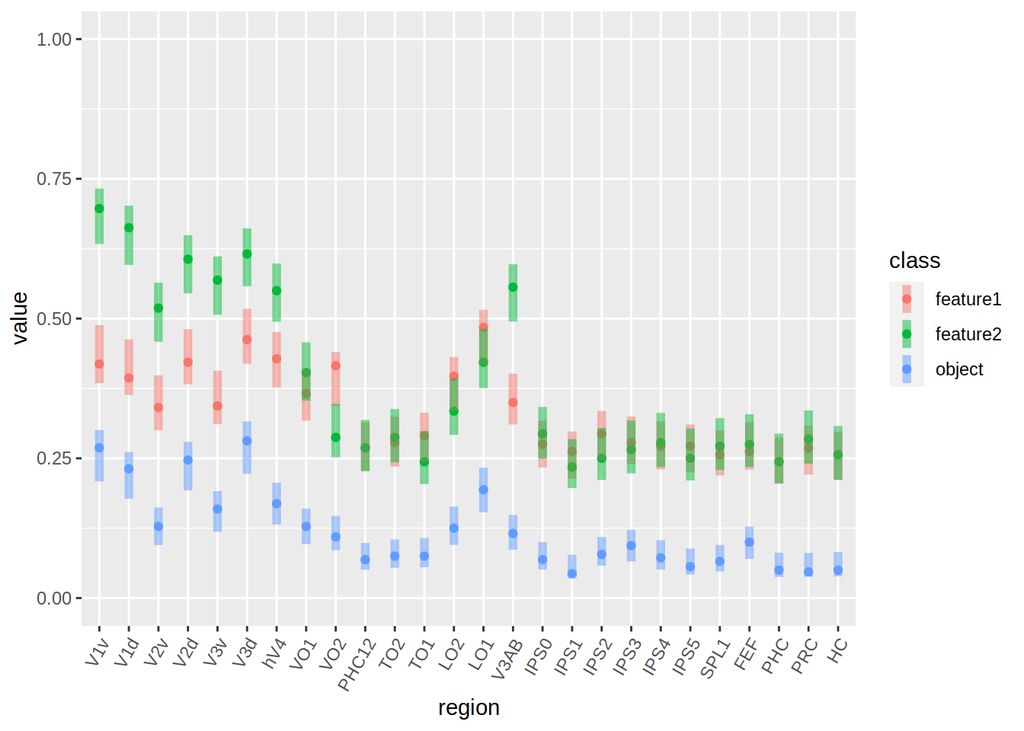

```r
plot_d(d) +
  geom_linerange(
    aes(ymin=ymin,ymax=ymax, x=region, color=class),
    alpha = 0.5,
    size = 2,
    data = predictions2,
    inherit.aes = FALSE)
```

Bam! That’s great. The new model is able to match the data.

# Model 2.1

Now that the model is fitting the data accurately, more could be done to increase the precision of those predictions – to reduce the variability of the predictions. For example, it may be the case that regions with high scores on feature 1 also tend to have scores on feature 2. Currently, such correlations are not modeled. Here’s how the formula would be redefined, to add such correlations.

```r
f21 <- brmsformula(
  value ~ 0 + Intercept + class + (class | region),
  family = bernoulli)
```

The only difference is that the double bar in the model formula has been replaced with a single bar.

Adding correlations often causes the model to stop converging. For these data, that was not the case; the model estimated the correlation parameters just fine.

```r
fit21 <- brm(
  formula = f21,
  data = d,
  prior = p,
  chains = 3,
  cores = 3,
  backend = "cmdstanr")
```

```
## Running MCMC with 3 parallel chains...
##
## Chain 1 Iteration:    1 / 2000 [  0%]  (Warmup)
## Chain 2 Iteration:    1 / 2000 [  0%]  (Warmup)
## Chain 3 Iteration:    1 / 2000 [  0%]  (Warmup)
## Chain 1 Iteration:  100 / 2000 [  5%]  (Warmup)
## Chain 2 Iteration:  100 / 2000 [  5%]  (Warmup)
## Chain 3 Iteration:  100 / 2000 [  5%]  (Warmup)
## Chain 1 Iteration:  200 / 2000 [ 10%]  (Warmup)
## Chain 3 Iteration:  200 / 2000 [ 10%]  (Warmup)
## Chain 2 Iteration:  200 / 2000 [ 10%]  (Warmup)
## Chain 1 Iteration:  300 / 2000 [ 15%]  (Warmup)
## Chain 3 Iteration:  300 / 2000 [ 15%]  (Warmup)
## Chain 2 Iteration:  300 / 2000 [ 15%]  (Warmup)
## Chain 1 Iteration:  400 / 2000 [ 20%]  (Warmup)
## Chain 2 Iteration:  400 / 2000 [ 20%]  (Warmup)
## Chain 3 Iteration:  400 / 2000 [ 20%]  (Warmup)
## Chain 1 Iteration:  500 / 2000 [ 25%]  (Warmup)
## Chain 3 Iteration:  500 / 2000 [ 25%]  (Warmup)
## Chain 2 Iteration:  500 / 2000 [ 25%]  (Warmup)
## Chain 1 Iteration:  600 / 2000 [ 30%]  (Warmup)
## Chain 3 Iteration:  600 / 2000 [ 30%]  (Warmup)
## Chain 1 Iteration:  700 / 2000 [ 35%]  (Warmup)
## Chain 2 Iteration:  600 / 2000 [ 30%]  (Warmup)
## Chain 3 Iteration:  700 / 2000 [ 35%]  (Warmup)
## Chain 1 Iteration:  800 / 2000 [ 40%]  (Warmup)
## Chain 2 Iteration:  700 / 2000 [ 35%]  (Warmup)
## Chain 3 Iteration:  800 / 2000 [ 40%]  (Warmup)
## Chain 1 Iteration:  900 / 2000 [ 45%]  (Warmup)
## Chain 2 Iteration:  800 / 2000 [ 40%]  (Warmup)
## Chain 3 Iteration:  900 / 2000 [ 45%]  (Warmup)
## Chain 1 Iteration: 1000 / 2000 [ 50%]  (Warmup)
## Chain 1 Iteration: 1001 / 2000 [ 50%]  (Sampling)
## Chain 2 Iteration:  900 / 2000 [ 45%]  (Warmup)
## Chain 1 Iteration: 1100 / 2000 [ 55%]  (Sampling)
## Chain 3 Iteration: 1000 / 2000 [ 50%]  (Warmup)
## Chain 3 Iteration: 1001 / 2000 [ 50%]  (Sampling)
## Chain 2 Iteration: 1000 / 2000 [ 50%]  (Warmup)
## Chain 2 Iteration: 1001 / 2000 [ 50%]  (Sampling)
## Chain 1 Iteration: 1200 / 2000 [ 60%]  (Sampling)
```

[output cut: 20 more lines]

```
## Chain 1 Iteration: 1900 / 2000 [ 95%]  (Sampling)
## Chain 2 Iteration: 1800 / 2000 [ 90%]  (Sampling)
## Chain 1 Iteration: 2000 / 2000 [100%]  (Sampling)
## Chain 1 finished in 409.6 seconds.
## Chain 3 Iteration: 1800 / 2000 [ 90%]  (Sampling)
## Chain 2 Iteration: 1900 / 2000 [ 95%]  (Sampling)
## Chain 3 Iteration: 1900 / 2000 [ 95%]  (Sampling)
## Chain 2 Iteration: 2000 / 2000 [100%]  (Sampling)
## Chain 2 finished in 426.8 seconds.
## Chain 3 Iteration: 2000 / 2000 [100%]  (Sampling)
## Chain 3 finished in 432.7 seconds.
##
## All 3 chains finished successfully.
## Mean chain execution time: 423.0 seconds.
## Total execution time: 433.4 seconds.
```

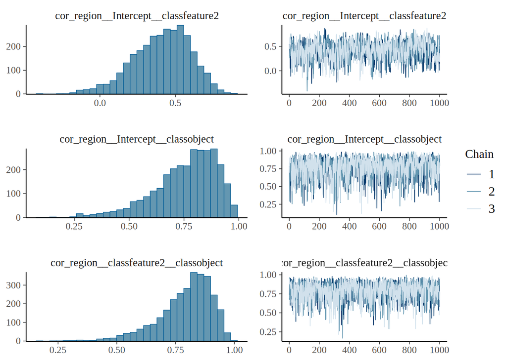

```r
plot(fit21, pars = "cor", combo = c("hist","trace"), bins=40)
```

It’s a bit hard to tell, but the predictions for each region do appear slightly more precise (the bars are slightly narrower).

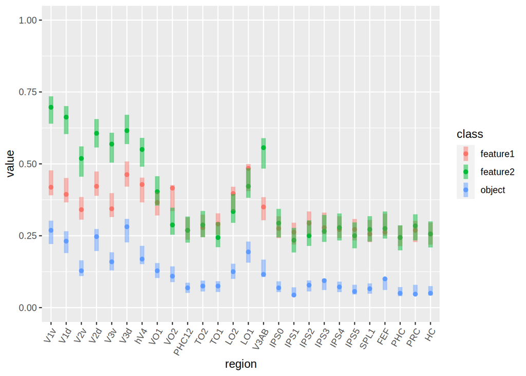

```r
predictions21 <- get_predictions(fit21, d, region, class)
plot_d(d) +
  geom_linerange(
    aes(ymin=ymin,ymax=ymax, x=region, color=class),
    alpha = 0.5,
    size = 2,
    data = predictions21,
    inherit.aes = FALSE)
```

# Model 2.2

The next model will do something tricky. At this point, trials are not modeled directly. That is, each of the 320 observations per region per class are treated as draws from the same variable. But, there could be a parameter associated with each trial. The idea is that we have repeated information about each trial, given that there are 26 measurements per trial. So, this parameter tries to account for how, e.g., how perhaps all brain regions did unexpectedly poorly on some particular trial. To do this, it probably makes the most sense to treat trials hierarchically.

```r
f22 <- brmsformula(
  value ~ 0 + Intercept + class + (class | region) + (1 || trial),
  family = bernoulli)

fit22 <- brm(
  formula = f22,
  data = d,
  prior = p,
  chains = 3,
  cores = 3,
  backend = "cmdstanr")
```

```
## Running MCMC with 3 parallel chains...
##
## Chain 1 Iteration:    1 / 2000 [  0%]  (Warmup)
## Chain 3 Iteration:    1 / 2000 [  0%]  (Warmup)
## Chain 2 Iteration:    1 / 2000 [  0%]  (Warmup)
## Chain 3 Iteration:  100 / 2000 [  5%]  (Warmup)
## Chain 1 Iteration:  100 / 2000 [  5%]  (Warmup)
## Chain 3 Iteration:  200 / 2000 [ 10%]  (Warmup)
## Chain 1 Iteration:  200 / 2000 [ 10%]  (Warmup)
## Chain 2 Iteration:  100 / 2000 [  5%]  (Warmup)
## Chain 3 Iteration:  300 / 2000 [ 15%]  (Warmup)
## Chain 1 Iteration:  300 / 2000 [ 15%]  (Warmup)
## Chain 2 Iteration:  200 / 2000 [ 10%]  (Warmup)
## Chain 3 Iteration:  400 / 2000 [ 20%]  (Warmup)
## Chain 1 Iteration:  400 / 2000 [ 20%]  (Warmup)
## Chain 2 Iteration:  300 / 2000 [ 15%]  (Warmup)
## Chain 3 Iteration:  500 / 2000 [ 25%]  (Warmup)
## Chain 1 Iteration:  500 / 2000 [ 25%]  (Warmup)
## Chain 2 Iteration:  400 / 2000 [ 20%]  (Warmup)
## Chain 3 Iteration:  600 / 2000 [ 30%]  (Warmup)
## Chain 1 Iteration:  600 / 2000 [ 30%]  (Warmup)
## Chain 2 Iteration:  500 / 2000 [ 25%]  (Warmup)
## Chain 3 Iteration:  700 / 2000 [ 35%]  (Warmup)
## Chain 1 Iteration:  700 / 2000 [ 35%]  (Warmup)
## Chain 2 Iteration:  600 / 2000 [ 30%]  (Warmup)
## Chain 3 Iteration:  800 / 2000 [ 40%]  (Warmup)
## Chain 1 Iteration:  800 / 2000 [ 40%]  (Warmup)
## Chain 2 Iteration:  700 / 2000 [ 35%]  (Warmup)
## Chain 3 Iteration:  900 / 2000 [ 45%]  (Warmup)
## Chain 1 Iteration:  900 / 2000 [ 45%]  (Warmup)
## Chain 2 Iteration:  800 / 2000 [ 40%]  (Warmup)
## Chain 3 Iteration: 1000 / 2000 [ 50%]  (Warmup)
## Chain 3 Iteration: 1001 / 2000 [ 50%]  (Sampling)
## Chain 1 Iteration: 1000 / 2000 [ 50%]  (Warmup)
## Chain 2 Iteration:  900 / 2000 [ 45%]  (Warmup)
## Chain 1 Iteration: 1001 / 2000 [ 50%]  (Sampling)
## Chain 3 Iteration: 1100 / 2000 [ 55%]  (Sampling)
## Chain 1 Iteration: 1100 / 2000 [ 55%]  (Sampling)
## Chain 2 Iteration: 1000 / 2000 [ 50%]  (Warmup)
## Chain 2 Iteration: 1001 / 2000 [ 50%]  (Sampling)
```

[output cut: 20 more lines]

```
## Chain 2 Iteration: 1700 / 2000 [ 85%]  (Sampling)
## Chain 3 Iteration: 1900 / 2000 [ 95%]  (Sampling)
## Chain 1 Iteration: 1900 / 2000 [ 95%]  (Sampling)
## Chain 2 Iteration: 1800 / 2000 [ 90%]  (Sampling)
## Chain 3 Iteration: 2000 / 2000 [100%]  (Sampling)
## Chain 3 finished in 440.4 seconds.
## Chain 1 Iteration: 2000 / 2000 [100%]  (Sampling)
## Chain 1 finished in 441.1 seconds.
## Chain 2 Iteration: 1900 / 2000 [ 95%]  (Sampling)
## Chain 2 Iteration: 2000 / 2000 [100%]  (Sampling)
## Chain 2 finished in 454.8 seconds.
##
## All 3 chains finished successfully.
## Mean chain execution time: 445.4 seconds.
## Total execution time: 455.0 seconds.
```

Great news that the model fit. Though, I’m not entirely sure what’s the best way to plot these predictions, to visualize whether the additional trial parameter helped (perhaps something like a moving window, tracking the average accuracy across time?). Instead, we can compare the leave-one-out cross-validation scores of the last two models, asking whether the additional parameters associated with each trial were worth the added complexity.

```r
fit21 <- add_criterion(fit21, "loo")
fit22 <- add_criterion(fit22, "loo")
```

```r
loo_compare(fit21, fit22, criterion = "loo")
```

```
##       elpd_diff se_diff
## fit22    0.0       0.0
## fit21 -105.8      14.7
```

The output shows the loss in the cross-validation score, relative to the best model (so, the best model has a loss of 0). Given that this is a Bayesian cross-validation, there is also a measure of the uncertainty in those predictive losses, the standard error of the difference. There are no hard rules about how many standard errors signify something important, but more than 3-4 are usually worth paying attention to.

# FCI

```r
fci <- posterior_predict(fit22, cores=3) %>%
  magrittr::set_colnames(1:ncol(.)) %>%
  as_tibble() %>%
  mutate(.draw = 1:n()) %>%
  pivot_longer(
    cols = c(-.draw),
    names_to = "observation",
    names_transform = list(observation = as.numeric),
    values_to = "post") %>%
  group_nest(.draw) %>%
  mutate(data = map(.x=data, .f= bind_cols, d)) %>%
  unnest(data) %>%
  select(-value, -observation) %>%
  pivot_wider(names_from = "class", values_from = "post") %>%
  mutate(prediction = feature1*feature2) %>%
  group_by(.draw, participant, region) %>%
  summarise(
    prediction = mean(prediction),
    empirical = mean(object),
    .groups = "drop") %>%
  mutate(fci = log(empirical / prediction))
```

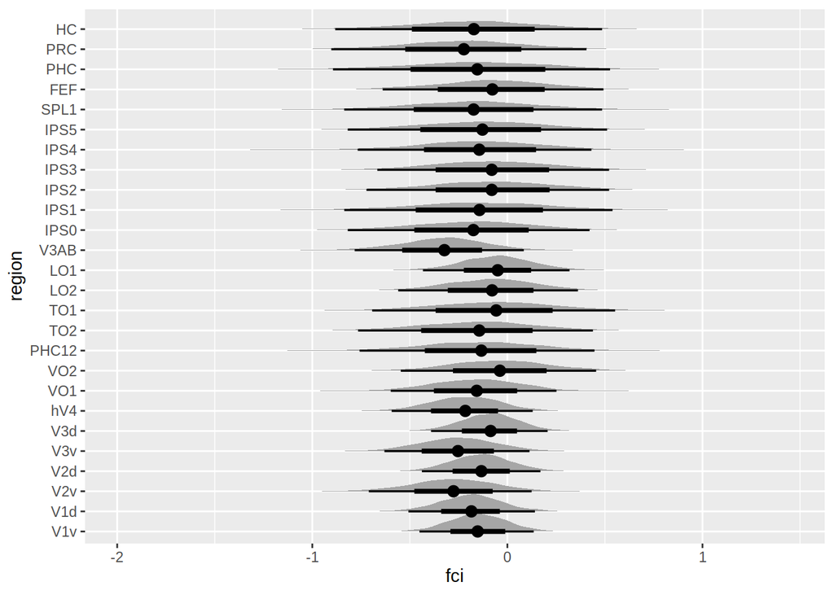

```r
fci %>%
  ggplot(aes(x = fci, y = region)) +
  tidybayes::stat_halfeye()
```

# Including Participants

Up to this point, we’ve only analyzed one participant. But there are three available. Presumably, all of these parameters vary across participants. Unfortunately, it is very hard to estimate this variability with only three participants. But we’ll give it a shot, in part to see what can go wrong with a model.

Here’s loading the data.

```r
d_all <- munge(c(
  here::here("data-raw", "roi_class_results_LDA.mat"),
  here::here("data-raw", "roi_class_results_LDA_2.mat"),
  here::here("data-raw", "roi_class_results_LDA_3.mat")))
d_all
```

```
## # A tibble: 74,880 x 5
##    participant region trial class    value
##    <fct>       <fct>  <fct> <fct>    <lgl>
##  1 1           V1v    1     feature1 TRUE
##  2 1           V1v    1     feature2 TRUE
##  3 1           V1v    1     object   TRUE
##  4 1           V1v    2     feature1 TRUE
##  5 1           V1v    2     feature2 FALSE
##  6 1           V1v    2     object   FALSE
##  7 1           V1v    3     feature1 FALSE
##  8 1           V1v    3     feature2 TRUE
##  9 1           V1v    3     object   FALSE
## 10 1           V1v    4     feature1 TRUE
## # … with 74,870 more rows
```

Here’s plotting the data, broken down by participant.

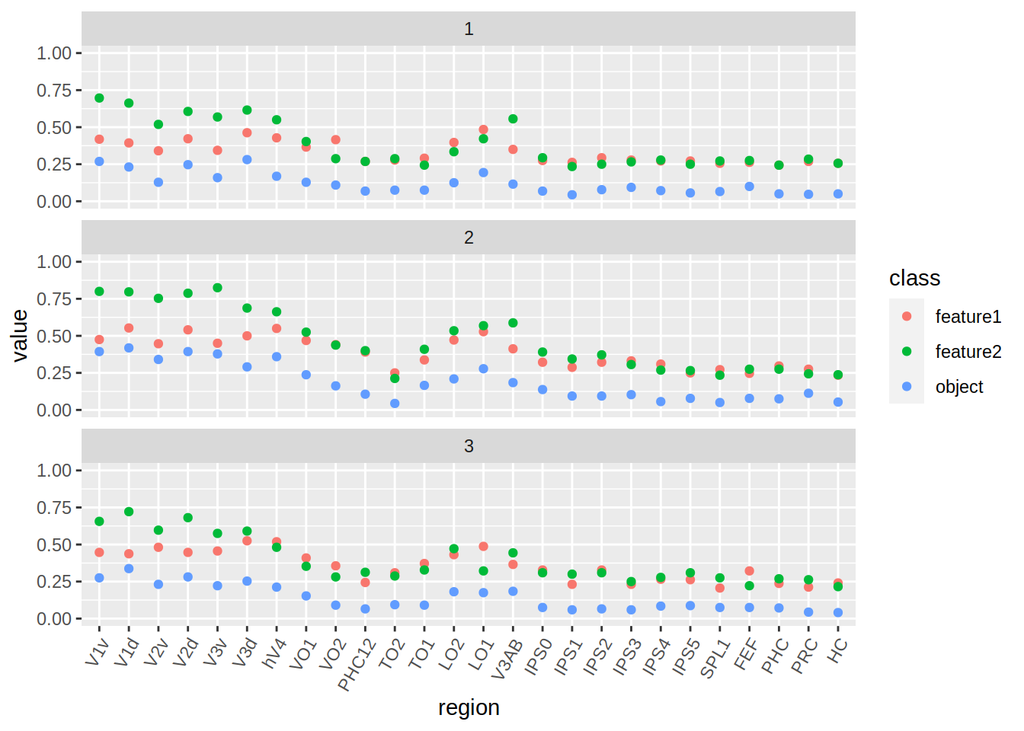

```r
d_all %>%
  group_by(region, class, participant) %>%
  summarise(value = mean(value), .groups = "drop") %>%
  ggplot(aes(x=region, y = value, color=class)) +
  geom_point() +
  ylim(c(0,1)) +
  facet_wrap(~participant, ncol=1) +
  theme(axis.text.x = element_text(angle=60, hjust=1))
```

The data look very consistent across participants.

```r
f3 <- brmsformula(
  value ~ 0 + Intercept + class + (class | region ) + (1 || participant),
  family = bernoulli)

p3 <- p + prior(normal(0, 2), class = "sd", group = "participant")

fit3 <- brm(
  formula = f3,
  data = d_all,
  prior = p3,
  chains = 3,
  cores = 3,
  backend = "cmdstanr")
```

I haven’t saved that model in the rmarkdown file, because running it takes a while. But if you did run it, you would notice that it prints a warning about divergences Those divergences indicate that the posterior distribution, as estimated by Stan, is likely not a good reflection of the true posterior distribution. Divergences are a part of a huge topic. The short of it is that any divergences at all are a sign that something is wrong. Occasionally, divergences can be removed by tweaking Stan’s algorithm for sampling (e.g., by setting `adapt_delta=.99` when calling the function `brm`). Often, it requires changing the model. For some more detail, you might [browse the Stan forum](https://discourse.mc-stan.org/), look at a few of [these case studies](https://betanalpha.github.io/writing/), or look through some of the [official Stan documentation](https://mc-stan.org/users/documentation/).

At this early stage, there might not be much point in spending a long time trying to get the model to fit with just three participants, since the issues may go away with more participants. If you wanted to fit all participants, you could try just ignoring potential variability due to participants, as follows.

```r
f30 <- brmsformula(
  value ~ 0 + Intercept + class + (class | region ),
  family = bernoulli)

fit3 <- brm(
  formula = f30,
  data = d_all,
  prior = p,
  chains = 3,
  cores = 3,
  backend = "cmdstanr")
```

# Next Steps

1. Try out different priors. The priors defined above might work, but it’s a good idea to see how those priors translate into predictions. Take a look at the help page for the `brm` function, and notice that you can run it with the argument `sample_prior="only"` to get samples from just the prior distribution. You could then plot those predictions, as before.
2. What’s a good way to plot predictions for each trial, to check why the by-trial parameter was so helpful?
3. Refit the model with participant-level parameters, using simulated data. This could be done by sampling from the prior and then using the function `posterior_predict()` to generate predictions with those samples. In particular, you can use the `newdata` argument to `posterior_predict()` to generate predictions for additional participants.
4. Given these model predictions, how should we calculate an FCI? I’m not entirely sure about this.
5. Once the model has settled down a bit (i.e., when it’s more clear exactly which parameters will be included), it would be a good idea to run a few extra validity checks. Such checks are another big topic.
[^1]: as with any linear models, there is a lot of flexibility in how to parameterize the intercept. In the following, the intercept will correspond to how well easily one of the classes is predicted, arbitrarily pinned to feature1. This means that $\beta_1$ will be a vector of length 2, whose interpretations are roughly how much easier it is to predict feature2 relative to feature1, and how much easier it is to predict an object relative to feature1.